# t-SNE with Clustar Output

Clustar returns groups containing each celestial object detected within FITS images. Here, that output is used as the input to a t-SNE model that maps each image to a low-dimensional representation.

## Setup

Set options and directory containing images; import packages. Option `im_type` specifies whether to use original images or residuals from a bivariate Gaussian fit.

```python
im_type = 'original'
# im_type = 'residuals'
```

```python
#standard packages
import numpy as np
import pandas as pd
import os
import time
import warnings
warnings.filterwarnings('ignore')

#viz
import matplotlib.pyplot as plt
from matplotlib.offsetbox import OffsetImage, AnnotationBbox
import seaborn as sns

#astropy (for image loading)
from astropy.io import fits

#data prep
from skimage.transform import resize

#ml packages
from sklearn import manifold
from sklearn import mixture
```

## Data from Clustar

```python
from clustar.search import Clustar
```

```python
#set path to folder containing FITS images

fits_path = PATH_TO_FOLDER #update to where you have images saved
os.chdir(fits_path)
files = os.listdir()
```

```python
#make sure only fits in list
files = [f for f in files if '.fits' in f]

#ran into an issue where each file showed up twice in listdir, once with ._ prefixed
files = [f for f in files if not f.startswith('._')]
```

```python
%%time
cs = Clustar()
output = cs.run(files)
```

```
File: 585/585 | Flagged: 249
```

```
CPU times: user 9min 29s, sys: 22.5 s, total: 9min 51s
Wall time: 1h 40min 53s
```

```python
#get size of largest image

size = 0
for group in output:
    if np.shape(group['data'])[0] > size:
        size = np.shape(group['data'])[0]
```

```python
#resize groups to match largest image
#using skimage resize function

data = np.empty([len(output)*4, size, size]) # *4 to make room for data augmentation later
file_list = ['']*(len(output)*4)
flag_list = ['']*(len(output)*4)

i = 0
for group in output:
    if im_type == 'residuals':
        resized = resize(np.array(group['residuals']), (size, size), anti_aliasing=True)
    else:
        resized = resize(np.array(group['data']), (size, size), anti_aliasing=True)
    data[i] = resized
    file_list[i] = group['file']
    flag_list[i] = group['flag']
    i += 1
```

```python
#data augmentation (rotations of 90, 180, 270 degrees)
#used combinations of numpy transpose and flip to achieve rotations for speed

for group in range(len(output)):
    rot90 = np.flip(data[group], axis = 1).T
    rot180 = np.flip(data[group])
    rot270 = np.flip(data[group], axis = 0).T

    data[i] = rot90
    file_list[i] = output[group]['file']
    flag_list[i] = output[group]['flag']
    i += 1
    data[i] = rot180
    file_list[i] = output[group]['file']
    flag_list[i] = output[group]['flag']
    i += 1
    data[i] = rot270
    file_list[i] = output[group]['file']
    flag_list[i] = output[group]['flag']
    i += 1
```

```python
num_groups = np.shape(data)[0]
```

```python
num_groups
```

```
2016
```

### TSNE

I used a [tutorial](https://sites.google.com/view/aas237mlworkshop/materials) from a machine learning workshop by the American Astronomical Society (AAS) to get started with t-SNE. I also relied on the scikit-learn [documentation](https://scikit-learn.org/stable/modules/generated/sklearn.manifold.TSNE.html) and this [How to Use t-SNE Effectively](https://distill.pub/2016/misread-tsne/) guide for determining how to tune my model.

I also used this StackOverflow [post](https://stackoverflow.com/questions/22566284/matplotlib-how-to-plot-images-instead-of-points) to figure out how to plot thumbnails in t-SNE dimensions.

```python
ims = data
num_groups = np.shape(ims)[0]

np.shape(ims)
```

```
(2016, 265, 265)
```

```python
#reshape data for t-SNE (1D array for each image instead of 2D)

images_tsne = np.zeros((num_groups, size*size))
for ii in range(num_groups):
    images_tsne[ii,:] = ims[ii].flatten()
```

```python
images_tsne.shape
```

```
(2016, 70225)
```

```python
#get max intensity of each image
maxes = np.max(images_tsne, axis = 1)
```

```python
#rescale images by dividing each by its max
images_tsne = images_tsne/maxes[:, None]
```

```python
#run t_SNE

tsne_model = manifold.TSNE(n_components=3,perplexity=50,learning_rate=400,n_iter=3000,
                           init='pca', random_state=5, early_exaggeration=12)

print("Running T-SNE . . .")
t0 = time.time()
tsne_output = tsne_model.fit_transform(images_tsne)
print("Time to run TSNE: %.2fs" % (time.time() - t0))
```

```
Running T-SNE . . .
Time to run TSNE: 447.50s
```

```python
#put t-SNE results in dataframe
tsne_df = pd.DataFrame({'file': file_list, 'tsne_dim1': tsne_output[:, 0],
                        'tsne_dim2': tsne_output[:, 1], 'tsne_dim3': tsne_output[:, 2],
                        'image_max': maxes, 'flag': flag_list})
```

```python
#these images are known to have a non-bivariate Gaussian substructure
#so we use them to evaluate our results
tsne_df['known_substructure'] = np.where(tsne_df['file'].str.contains('HH270mms2|HOPS-56|HOPS-65|HOPS-124|HOPS-140|HOPS-157|HOPS-163'), 1, 0)
```

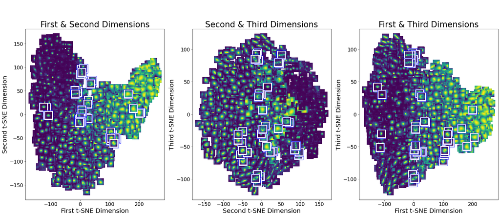

```python
#plot results in each pair of dimensions
#highlight images with a known substructure using a border

params = {'axes.labelsize': 20,
          'axes.titlesize': 26,
          'xtick.labelsize': 16,
          'ytick.labelsize': 16,
          'figure.titlesize': 26}
plt.rcParams.update(params)

fig, axs = plt.subplots(1, 3, figsize=(27, 10))

#first & second dimensions
axs[0].scatter(tsne_df['tsne_dim1'], tsne_df['tsne_dim2'])
axs[0].set_title('First & Second Dimensions')
axs[0].set_xlabel('First t-SNE Dimension')
axs[0].set_ylabel('Second t-SNE Dimension')

for i in range(len(data)):
    if tsne_df['known_substructure'][i] == 0:
        ab = AnnotationBbox(OffsetImage(data[i], zoom=0.08),
                            (tsne_df['tsne_dim1'][i], tsne_df['tsne_dim2'][i]), frameon=False)
        axs[0].add_artist(ab)

for i in range(len(data)):
    if tsne_df['known_substructure'][i] == 1:
        ab = AnnotationBbox(OffsetImage(data[i], zoom=0.08),
                            (tsne_df['tsne_dim1'][i], tsne_df['tsne_dim2'][i]),
                            bboxprops = dict(edgecolor='blue'))
        axs[0].add_artist(ab)

#second & third dimensions
axs[1].scatter(tsne_df['tsne_dim2'], tsne_df['tsne_dim3'])
axs[1].set_title('\n\nSecond & Third Dimensions')
axs[1].set_xlabel('Second t-SNE Dimension')
axs[1].set_ylabel('Third t-SNE Dimension')

for i in range(len(data)):
    if tsne_df['known_substructure'][i] == 0:
        ab = AnnotationBbox(OffsetImage(data[i], zoom=0.08),
                            (tsne_df['tsne_dim2'][i], tsne_df['tsne_dim3'][i]), frameon=False)
        axs[1].add_artist(ab)

for i in range(len(data)):
    if tsne_df['known_substructure'][i] == 1:
        ab = AnnotationBbox(OffsetImage(data[i], zoom=0.08),
                            (tsne_df['tsne_dim2'][i], tsne_df['tsne_dim3'][i]),
                            bboxprops = dict(edgecolor='blue'))
        axs[1].add_artist(ab)

#first & third dimensions
axs[2].scatter(tsne_df['tsne_dim1'], tsne_df['tsne_dim3'])
axs[2].set_title('\n\nFirst & Third Dimensions')
axs[2].set_xlabel('First t-SNE Dimension')
axs[2].set_ylabel('Third t-SNE Dimension')

for i in range(len(data)):
    if tsne_df['known_substructure'][i] == 0:
        ab = AnnotationBbox(OffsetImage(data[i], zoom=0.08),
                            (tsne_df['tsne_dim1'][i], tsne_df['tsne_dim3'][i]), frameon=False)
        axs[2].add_artist(ab)

for i in range(len(data)):
    if tsne_df['known_substructure'][i] == 1:
        ab = AnnotationBbox(OffsetImage(data[i], zoom=0.08),
                            (tsne_df['tsne_dim1'][i], tsne_df['tsne_dim3'][i]),
                            bboxprops = dict(edgecolor='blue'))
        axs[2].add_artist(ab)
```

The first dimension appears to represent the level to which the object fills the frame of the image, and the third dimension appears to encode the rotation angle of the object within the image. The second dimension is unclear in its visual representation.

### GMM

Because the more abnormal images appeared to be closer to the edges of the distribution of images in the t-SNE plots, I implemented a Gaussian Mixture Model to score images based on their distance from the center of the distribution.

I used this [example](https://scikit-learn.org/stable/auto_examples/mixture/plot_gmm_pdf.html#sphx-glr-auto-examples-mixture-plot-gmm-pdf-py) from the scikit-learn documentation for implementing a Gaussian mixture model.

```python
clf = mixture.GaussianMixture(n_components=2, covariance_type='full')
clf.fit(tsne_output)
```

```
GaussianMixture(covariance_type='full', init_params='kmeans', max_iter=100,
                means_init=None, n_components=2, n_init=1, precisions_init=None,
                random_state=None, reg_covar=1e-06, tol=0.001, verbose=0,
                verbose_interval=10, warm_start=False, weights_init=None)
```

```python
#score each image with model
#score is log-likelihood

scores = clf.score_samples(tsne_output)
tsne_df['score'] = scores
```

```python
#copy data and sort by score (lowest is furthest from center of distribution)

preds = tsne_df.copy()
preds = preds.sort_values(by = 'score').reset_index()
```

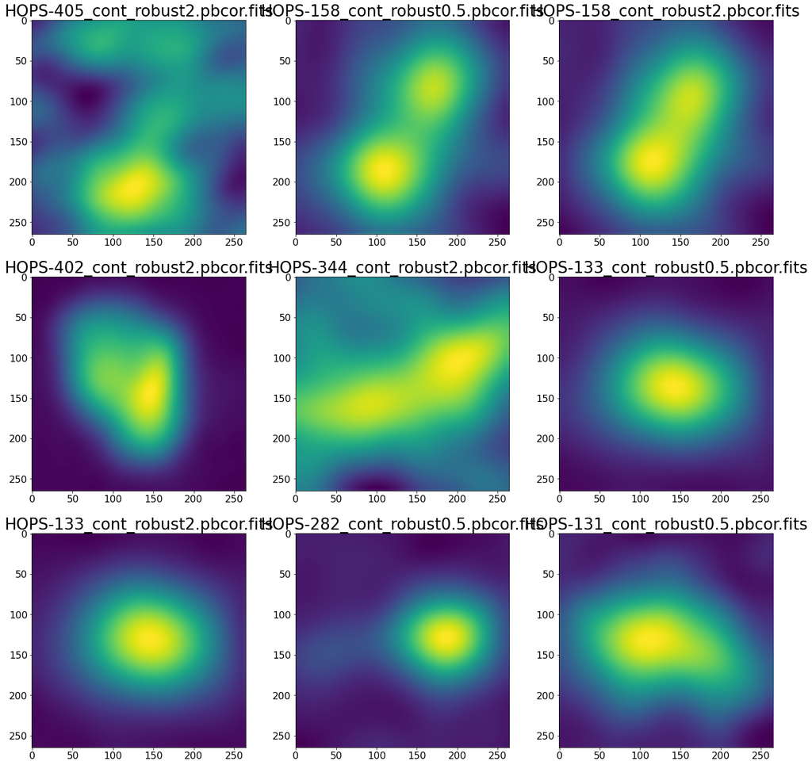

```python
#show most outlying images

rows = 3
cols = 3

params = {'axes.labelsize': 16,
          'axes.titlesize': 26,
          'xtick.labelsize': 16,
          'ytick.labelsize': 16,
          'figure.titlesize': 26}
plt.rcParams.update(params)

fig, axs = plt.subplots(rows, cols, figsize=(22, 22))

#show only one version of each image (don't show multiple augmentations of the same one)
i = 0
already_shown = []
inds = []
while len(already_shown) < rows*cols:
    if preds['file'][i] in already_shown:
        pass
    else:
        already_shown.append(preds['file'][i])
        inds.append(i)

    i += 1


j = 0
for ax in axs:
    for a in ax:
        ind = preds['index'][inds[j]]
        a.set_title(preds['file'][inds[j]])
        a.imshow(data[ind])

        j += 1
```

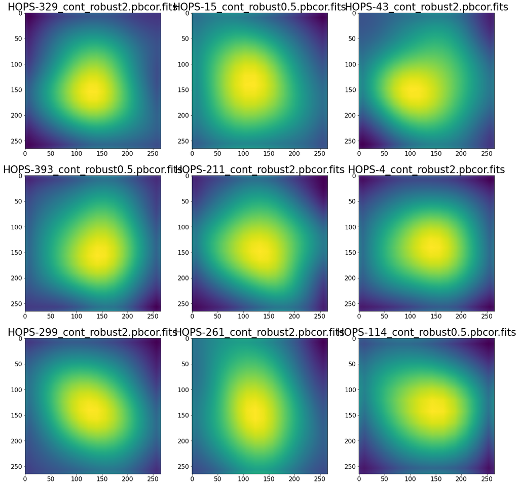

```python
#show least outlying images

params = {'axes.labelsize': 16,
          'axes.titlesize': 26,
          'xtick.labelsize': 16,
          'ytick.labelsize': 16,
          'figure.titlesize': 26}
plt.rcParams.update(params)

fig, axs = plt.subplots(rows, cols, figsize=(22, 22))

#show only one version of each image (don't show multiple augmentations of the same one)
i = preds.shape[0] - 1
already_shown = []
inds = []
while len(already_shown) < rows*cols:
    if preds['file'][i] in already_shown:
        pass
    else:
        already_shown.append(preds['file'][i])
        inds.append(i)

    i -= 1


j = 0
for ax in axs:
    for a in ax:
        ind = preds['index'][inds[j]]
        a.set_title(preds['file'][inds[j]])
        a.imshow(data[ind])

        j += 1
```